# DMAIC Example: A pizza delivery company

Catalina Bolancé

05/10/2021

*Date of this draft*: 05 octubre 2021

# 1 Background

# 2 Installing packages

install.packages(“e1071”)

install.packages(“ggplot2”)

install.packages(“gridExtra”)

# 3 Define

## 3.1 D.1: Clarify purpose

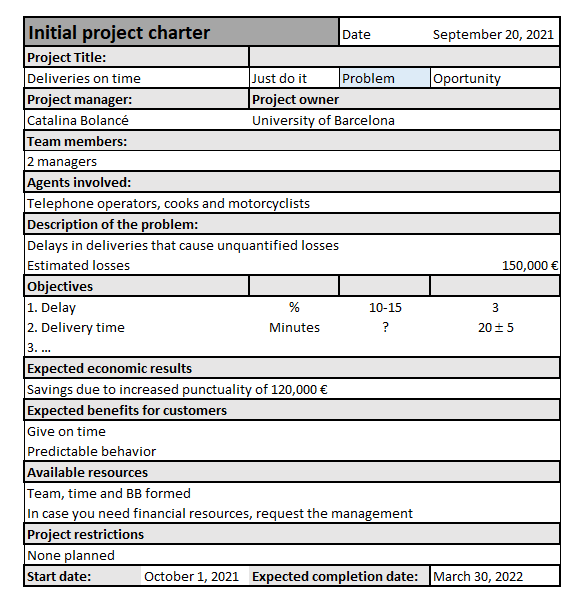

## 3.2 D.2: SIPOC

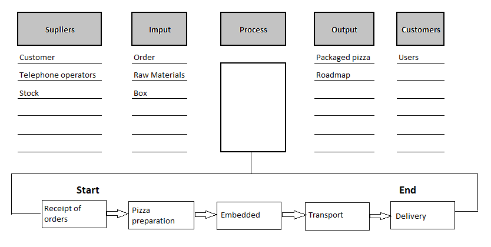

## 3.3 D.3 CTQ and VoC

**CTQ**

With “Focus Groups” and “Affinity Diagram” **the major discovery** was:

30 minutes is OK if the pizza arrives hot

**VoC**

Using a survey stratified by city:

- To confirm and quantify what had already been discovered
- To find issues related with the different kinds of pizza
- To explore the possibility of offering additional services

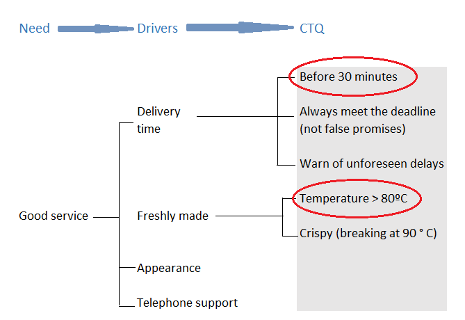

**Figure:** Customer CTQ characteristics

## 3.4 D.4 Business Case

The annual turnover of the 4 shops is 1,100,000 €.

The 15 % of delayed deliveries with 25% of discounts supposes a cost of 140,000 €.

Estimation has been validated by the finance director.

## 3.5 D.5 Final project charter

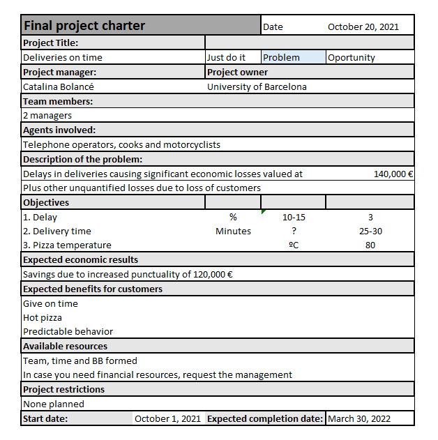

# 4 Measure

## 4.1 M.1 Asking questions and diagram process

The **questions** are:

- How long do the pizzas need to be delivered?
- At what temperature do pizzas arrive at client’s home?
- How long does it take from order to shipment and from shipment to delivery?
- Are there better and worse shops?
- Are there more delays some days than others?
- Are there more delays some hours than others?
- Are the most expensive orders delayed more that others?
- Have some motorcyclist higner delays than others?

The **diagram porcess** is:

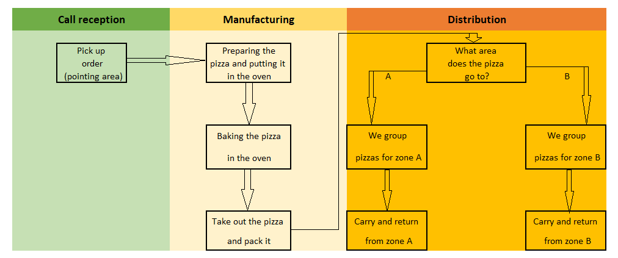

## 4.2 M.2 Review existing data and validate the measurement system

The **existing data** are:

- The measures that were available were not only scarce, but also incomplete (there was no information to answer questions) and unreliable
- For one month (September), the operator wrote down the time of the order and motorcyclist wrote down the delivery time
- There are not sure of the reliability of the measurement system

A **system to measure** delays (delivery time) and the temperature of the pizza when it reaches the customer was needed.

- The order form is converted into an “itinerant form”
- An operational definition of the measurement system is prepared
- A digital clock is placed visible to all, digital clocks are given to motorcyclist (synchronized) and thermometers are placed in the pizza boxes
- An explanation is given to everybody (telephone operators, cookers and motorcyclist) about the importance of having good data and the benefits of the study
- Validation: a discount is offered on the next order to customers that call telling the time when the pizza was received and if the pizza was hot, the supervisor writes down some times on the shop
- The study of the new measurement system shows that it is reliable enough

## 4.3 M.3 Collect new data

For a month data were collected (according to the defined system, that was improved a little bit) in the four shops, two in Madrid (M) and two in Barcelona (B)

| Shop | Years opened | Volume |
| --- | --- | --- |
| M1 | 4 | >600,000€ |
| M2 | 2 | 300,000€-600,000€ |
| B1 | 6 | <300,000€ |
| B2 | 3 | >800,000€ |

- It was easier to collect data from all orders
- It was decided to continue checking the validity of the measurement system
- The data collected in the order form could be stratified by: time, pizza type, city area and motorcyclist
- Some space for comments was provided

## 4.4 M.4 Answer questions (existing data)

**Number of deliveries** by shop.

```r
library(ggplot2)
library(gridExtra)
setwd("C:\\Clases\\EGE_2021_2022\\Theme II\\Practice2")

ndel<-read.table("Data_ndel.csv", header = T, sep = ",",stringsAsFactors = T)

summary(ndel)
```

```
      Day             Weekday      ShopB2           ShopM1        ShopM2
 Min.   : 1.00   Friday   :4   Min.   : 31.00   Min.   : 20   Min.   :13.00
 1st Qu.: 8.25   Monday   :5   1st Qu.: 37.00   1st Qu.: 28   1st Qu.:23.25
 Median :15.50   Saturday :4   Median : 43.00   Median : 31   Median :30.50
 Mean   :15.50   Sunday   :4   Mean   : 54.57   Mean   : 44   Mean   :37.57
 3rd Qu.:22.75   Thursday :4   3rd Qu.: 66.00   3rd Qu.: 59   3rd Qu.:48.25
 Max.   :30.00   Tuesday  :5   Max.   :120.00   Max.   :102   Max.   :84.00
                 Wednesday:4
     ShopB1           day              Type
 Min.   :13.00   Min.   : 1.00   Friday  : 4
 1st Qu.:17.25   1st Qu.: 8.25   Saturday: 4
 Median :22.00   Median :15.50   Work day:22
 Mean   :30.83   Mean   :15.50
 3rd Qu.:40.75   3rd Qu.:22.75
 Max.   :72.00   Max.   :30.00
```

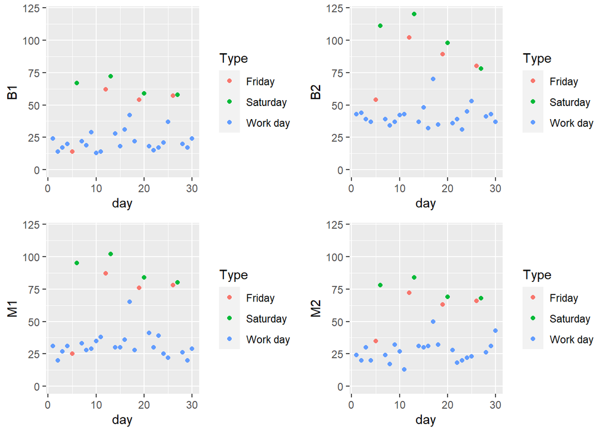

```r
p1<-qplot(day,ShopB1,data = ndel, ylab = "B1",ylim = c(0,120),color=Type)
p2<-qplot(day,ShopB2,data = ndel, ylab = "B2",ylim = c(0,120),color=Type)
p3<-qplot(day,ShopM1,data = ndel, ylab = "M1",ylim = c(0,120),color=Type)
p4<-qplot(day,ShopM2,data = ndel, ylab = "M2",ylim = c(0,120),color=Type)
grid.arrange(p1,p2,p3,p4,nrow=2)
```

The four shops have similar behavior for the number of deliveries. We decide work with one shop, the B2

In total we have n=1637 deliveries in a month (30 days).

**How long are pizzas delayed?. Are there more delays some days than others?**

```r
library(e1071)
tdelay<-read.table("delivtime.csv", header = T, sep = ";")

# Summary delayed time by day (weekday versus holiday)
descrip = matrix(0,2,8)
colnames(descrip) <-  c("N","Min", "Mean", "Median","Max", "STD", "Skew","Kur")
rownames(descrip) <-  c("Weekday", "Holiday")
descrip[,1] <- aggregate(time ~ type, data=tdelay, length)$time
descrip[,2] <- aggregate(time ~ type, data=tdelay, min)$time
descrip[,3] <- aggregate(time ~ type, data=tdelay, mean)$time
descrip[,4] <- aggregate(time ~ type, data=tdelay, median)$time
descrip[,5] <- aggregate(time ~ type, data=tdelay, max)$time
descrip[,6] <- sqrt(aggregate(time ~ type, data=tdelay, var)$time)
descrip[,7] <- aggregate(time ~ type, data=tdelay, skewness)$time
descrip[,8] <- aggregate(time ~ type, data=tdelay, kurtosis)$time
knitr::kable(descrip,digits=2, caption="Descriptive statistics")
```

Descriptive statistics

[output not shown]

```r
# Six sigma analysis
tdelayw<-tdelay[tdelay$type==1,]
nrow(tdelayw)
```

```
[1] 905
```

```r
tdelayh<-tdelay[tdelay$type==0,]
nrow(tdelayh)
```

```
[1] 732
```

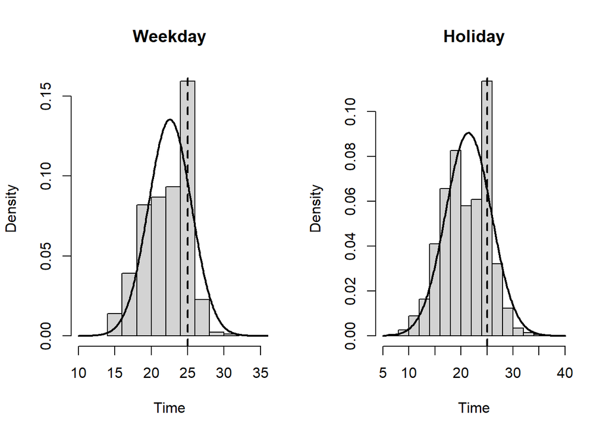

```r
gridw<-c(100:400)/10
fnormw<-dnorm(gridw,mean=22.55,sd=2.95)
fnormw<-cbind(gridw,fnormw)
gridh<-c(50:400)/10
fnormh<-dnorm(gridh,mean=21.42,sd=4.41)
fnormh<-cbind(gridh,fnormh)
par(mfrow=c(1,2))
hist(tdelayw$time,xlim = c(10,35),probability = T,xlab="Time",main = "Weekday")
lines(gridw,fnormw[,2],type="l",lwd=2,lty=1)
abline(v=25,lwd=2,lty=2)
hist(tdelayh$time,xlim = c(5,40),probability = T,xlab="Time",main = "Holiday")
lines(gridh,fnormh[,2],type="l",lwd=2,lty=1)
abline(v=25,lwd=2,lty=2)
```

For all day, the k Sigma process is analysed.

```r
# Calculate the "k sigma" process and numbers of faults by million opportunities
N<-nrow(tdelay)
Mindel<-min(tdelay$time)
Meandel<-mean(tdelay$time)
Mededel<-median(tdelay$time)
Maxdel<-max(tdelay$time)
Stddel<-sqrt(var(tdelay$time))
Skewdel<-skewness(tdelay$time)
Kurdel<-kurtosis(tdelay$time)
desc<-cbind(N,Mindel,Meandel,Mededel,Maxdel,Stddel,Skewdel,Kurdel)
knitr::kable(desc,digits=3, caption="Descriptive statistics")
```

Descriptive statistics

| N | Mindel | Meandel | Mededel | Maxdel | Stddel | Skewdel | Kurdel |
| --- | --- | --- | --- | --- | --- | --- | --- |
| 1637 | 7 | 22.045 | 23 | 35 | 3.721 | -0.428 | 0.101 |

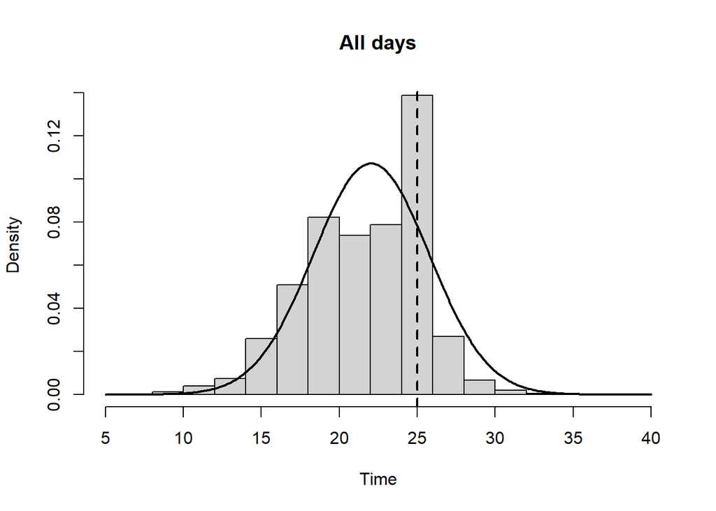

```r
grid<-c(50:400)/10
fnorm<-dnorm(grid,mean=22.045,sd=3.721)
fnorm<-cbind(grid,fnorm)

par(mfrow=c(1,1))
hist(tdelay$time,xlim = c(5,40),probability = T,xlab="Time",main = "All days")
lines(grid,fnorm[,2],type="l",lwd=2,lty=1)
abline(v=25,lwd=2,lty=2)
```

```r
nfaults<-(sum(tdelay$time>25)/nrow(tdelay))*1000000
print("Faults per million")
```

```
[1] "Faults per million"
```

```r
print(nfaults)
```

```
[1] 116676.8
```

```r
muhat<-mean(tdelay$time)
shat<-sqrt(var(tdelay$time))

k<-(25-muhat)/shat
print(k)
```

```
[1] 0.7941765
```

## 4.5 M.4 Answer questions (new data)

**How long do pizzas take to be delivered?**

```r
tdelay_new<-read.table("delivtime_new.csv", header = T, sep = ",")
summary(tdelay_new)
```

```
      Day            time           type
 Min.   : 1.0   Min.   : 5.0   Min.   :0.0000
 1st Qu.: 9.0   1st Qu.:18.0   1st Qu.:0.0000
 Median :15.0   Median :21.0   Median :1.0000
 Mean   :15.6   Mean   :20.5   Mean   :0.5528
 3rd Qu.:22.0   3rd Qu.:23.0   3rd Qu.:1.0000
 Max.   :30.0   Max.   :33.0   Max.   :1.0000
```

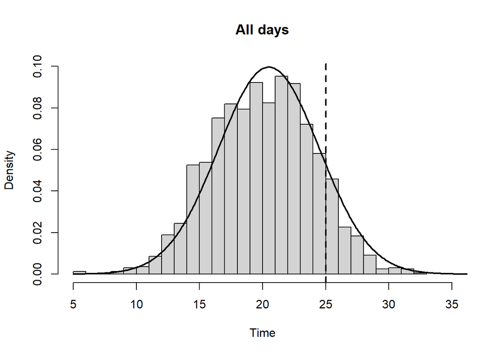

```r
grid<-c(50:400)/10
fnorm<-dnorm(grid,mean = 20.495,sd=4.002)
fnorm<-cbind(grid,fnorm)
par(mfrow=c(1,1))
hist(tdelay_new$time,xlim = c(5,35),ylim = c(0,0.1),probability = T,xlab="Time",main = "All days",20)
lines(grid,fnorm[,2],type="l",lwd=2,lty=1)
abline(v=25,lwd=2,lty=2)
```

```r
N<-nrow(tdelay_new)
Mindel<-min(tdelay_new$time)
Meandel<-mean(tdelay_new$time)
Mededel<-median(tdelay_new$time)
Maxdel<-max(tdelay_new$time)
Stddel<-sqrt(var(tdelay_new$time))
Skewdel<-skewness(tdelay_new$time)
Kurdel<-kurtosis(tdelay_new$time)
desc<-cbind(N,Mindel,Meandel,Mededel,Maxdel,Stddel,Skewdel,Kurdel)
knitr::kable(desc,digits=3, caption="Descriptive statistics")
```

Descriptive statistics

| N | Mindel | Meandel | Mededel | Maxdel | Stddel | Skewdel | Kurdel |
| --- | --- | --- | --- | --- | --- | --- | --- |
| 1637 | 5 | 20.495 | 21 | 33 | 4.002 | -0.046 | -0.173 |

```r
nfaults<-(sum(tdelay_new$time>25)/nrow(tdelay))*1000000
print("Faults per million")
```

```
[1] "Faults per million"
```

```r
print(nfaults)
```

```
[1] 104459.4
```

```r
muhat<-mean(tdelay_new$time)
shat<-sqrt(var(tdelay_new$time))

k<-(25-muhat)/shat
print(k)
```

```
[1] 1.12556
```

**At what temperature do pizzas arrive home?**

```r
ttemp<-read.table("temperature.csv", header = T, sep = ",")

N<-nrow(ttemp)
Mintem<-min(ttemp$temp)
Meantem<-mean(ttemp$temp)
Medtem<-median(ttemp$temp)
Maxtem<-max(ttemp$temp)
Stdtem<-sqrt(var(ttemp$temp))
Skewtem<-skewness(ttemp$temp)
Kurtem<-kurtosis(ttemp$temp)
desc<-cbind(N,Mintem,Meantem,Medtem,Maxtem,Stdtem,Skewtem,Kurtem)
knitr::kable(desc,digits=3, caption="Descriptive statistics")
```

Descriptive statistics

| N | Mintem | Meantem | Medtem | Maxtem | Stdtem | Skewtem | Kurtem |
| --- | --- | --- | --- | --- | --- | --- | --- |
| 200 | 69.505 | 82.123 | 82.11 | 94.904 | 4.856 | 0.013 | 0.016 |

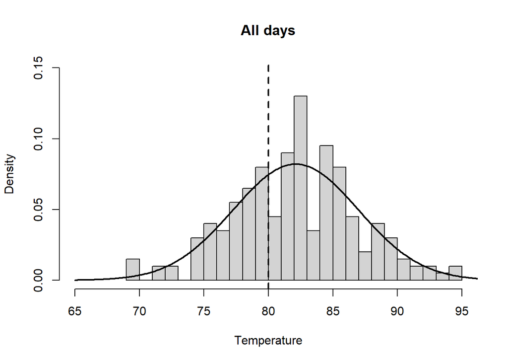

```r
grid<-c(650:1000)/10
fnorm<-dnorm(grid,mean = 82.12,sd=4.86)

fnorm<-cbind(grid,fnorm)
par(mfrow=c(1,1))
hist(ttemp$temp,xlim = c(65,95),ylim = c(0,0.15),probability = T,xlab="Temperature",main = "All days",20)
lines(grid,fnorm[,2],type="l",lwd=2,lty=1)
abline(v=80,lwd=2,lty=2)
```

```r
nfaults<-(sum(ttemp$temp<80)/nrow(ttemp))*1000000
print("faults per million")
```

```
[1] "faults per million"
```

```r
print(nfaults)
```

```
[1] 340000
```

```r
muhat<-mean(ttemp$temp)
shat<-sqrt(var(ttemp$temp))

k<-(muhat-80)/shat
print(k)
```

```
[1] 0.4370706
```

## 4.6 M.4 Answer questions

The first graphics and preliminary analysis showed, among other things:

- The problem was focused on delivery time
- There were differences among motorist
- Delivery times were more variable on weekends
- It seems that neither peaks (agglomerations) or order size or type of pizza were causing delays

## 4.7 M.5 Determine the starting point

Information about the behaviour of the process variables $X$’s.

# 5 Analysis

## 5.1 A.1 Refocus the project: Review the project charter

```r
1-pnorm(30,mean = 20.495,sd=4.002)
```

```
[1] 0.00877299
```

```r
sum(tdelay_new$time>30)/nrow(tdelay_new)
```

```
[1] 0.006108735
```

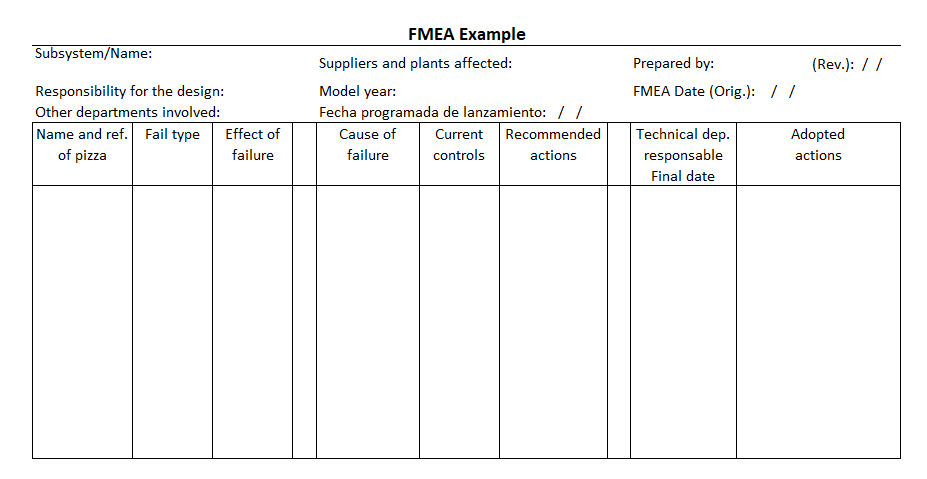

- Concentrate on the distribution time and ensure that the pizza arrives hot
- Consider a new goal: process with less that $0.5\%$ of deliveries with $t>30\, min.$ (revise Final Project Charter)
- Make small improvement and be more rigorous with internal processes

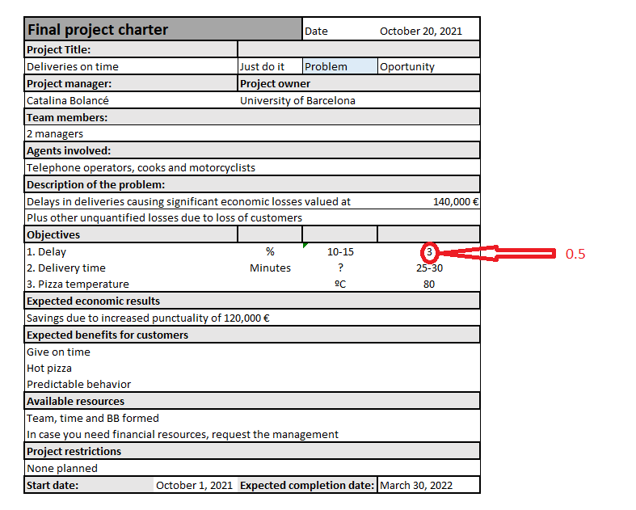

## 5.2 A.2 Hypothesis generation (possibles causes)

- The delivery temperature is a function of delivery time
- A brainstorming session on excessive tiem delivery causes gave the following diagram:

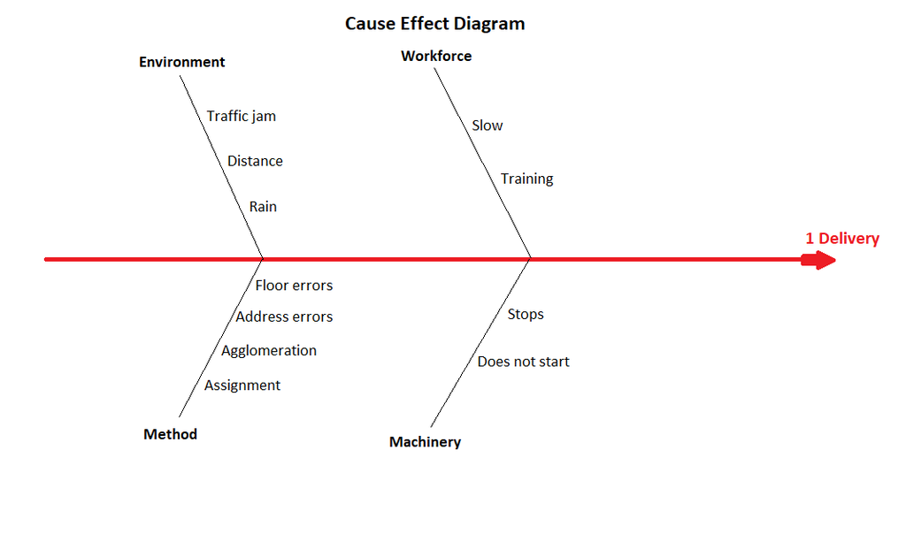

## 5.3 A.3 Hypothesis testing

Does de delivery temperature depend on the delivery time?
$$Temperature=102.24573-0.96653\times Time$$

```r
summary(lm(ttemp$temp ~ ttemp$time))
```

```
Call:
lm(formula = ttemp$temp ~ ttemp$time)

Residuals:
    Min      1Q  Median      3Q     Max
-9.3604 -1.9589  0.2043  1.9413  6.8144

Coefficients:
             Estimate Std. Error t value Pr(>|t|)
(Intercept) 102.24573    1.05972   96.48   <2e-16 ***
ttemp$time   -0.96653    0.04996  -19.35   <2e-16 ***
---
Signif. codes:  0 '***' 0.001 '**' 0.01 '*' 0.05 '.' 0.1 ' ' 1

Residual standard error: 2.864 on 198 degrees of freedom
Multiple R-squared:  0.654, Adjusted R-squared:  0.6523
F-statistic: 374.3 on 1 and 198 DF,  p-value: < 2.2e-16
```

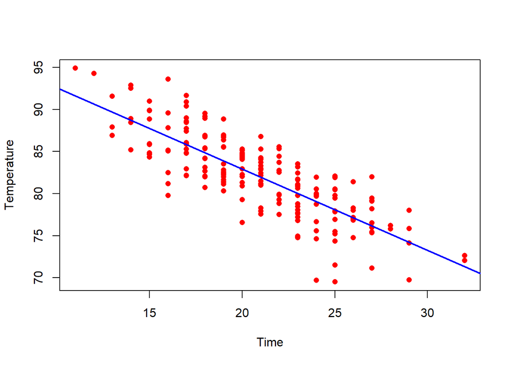

```r
plot(ttemp$time,ttemp$temp,pch=16,col="red",xlab="Time", ylab="Temperature")
abline(lm(ttemp$temp ~ ttemp$time), col = "blue",lwd=2)
```

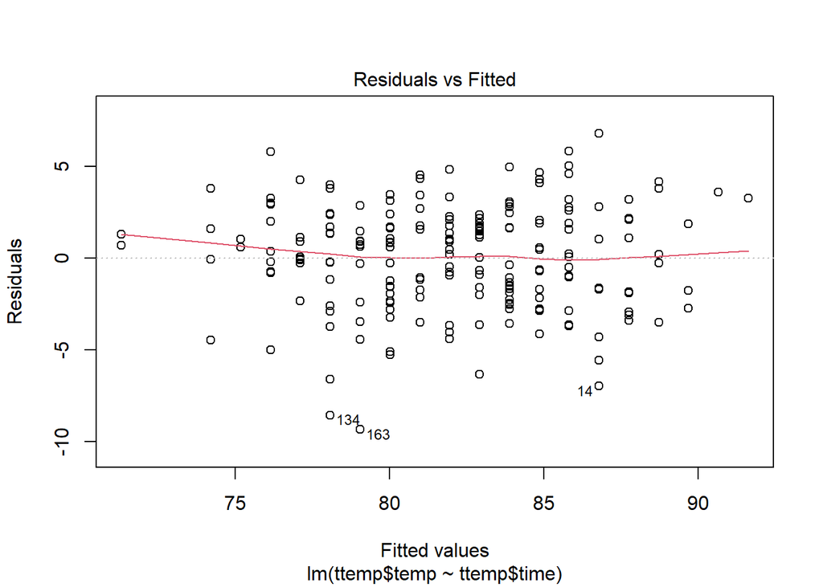

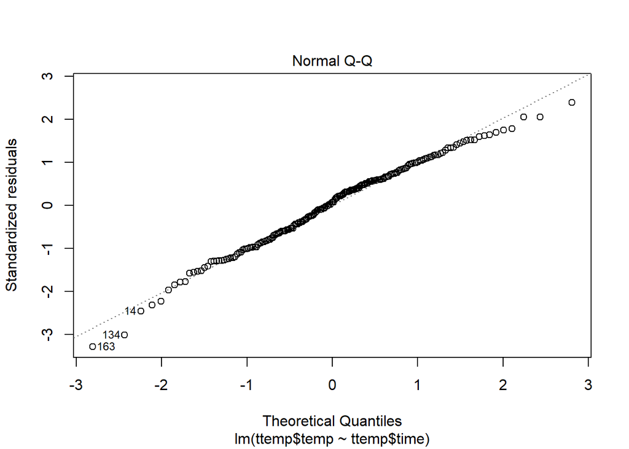

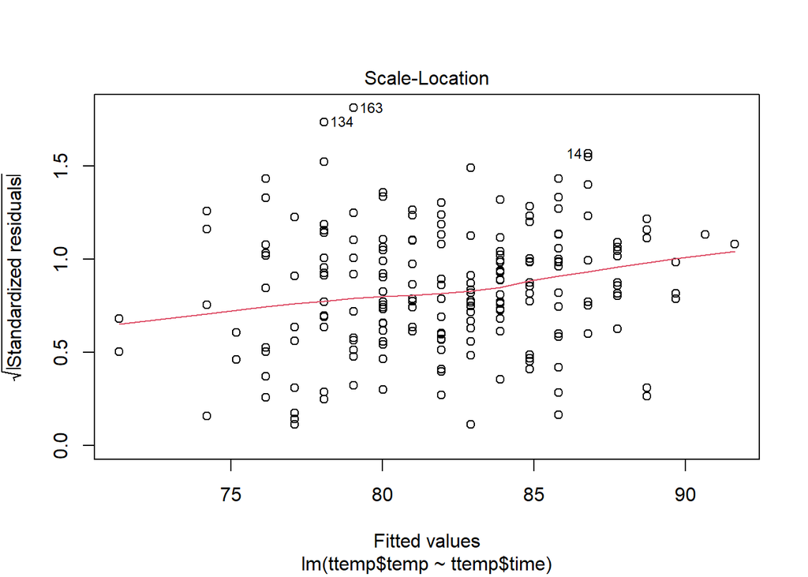

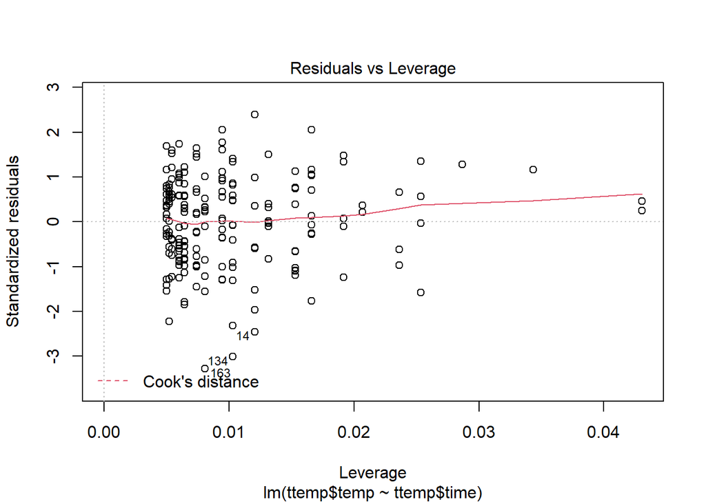

```r
plot(lm(ttemp$temp ~ ttemp$time))
```

Are there better and worse shops?

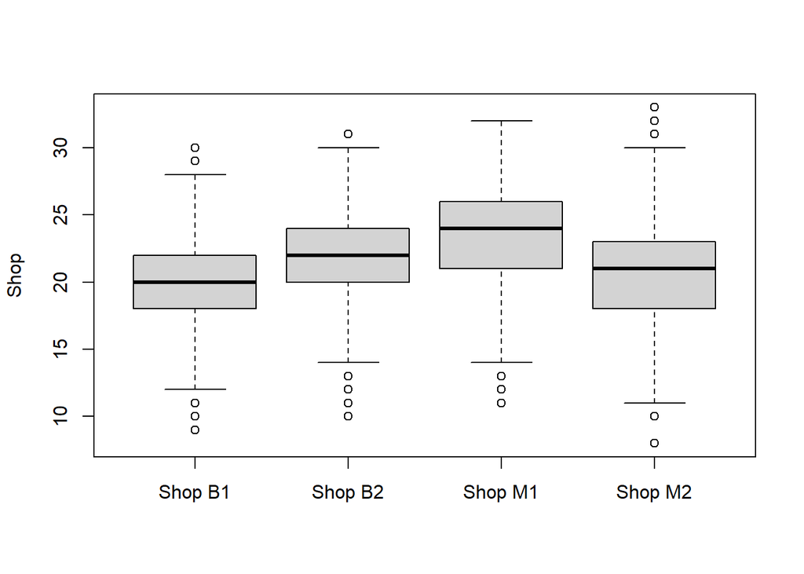

```r
tdel_sh<-read.table("tdelivshops.csv", header = T, sep = ",",stringsAsFactors = T)

boxplot(tdel_sh$time~tdel_sh$Shop,ylab = "Shop",xlab = "")
```

```r
summary(aov(time ~ Shop, data = tdel_sh))
```

```
              Df Sum Sq Mean Sq F value Pr(>F)
Shop           3   2544   848.1   60.29 <2e-16 ***
Residuals   1655  23283    14.1
---
Signif. codes:  0 '***' 0.001 '**' 0.01 '*' 0.05 '.' 0.1 ' ' 1
```

```r
tdel_sh$delay<-as.numeric(tdel_sh$time>30)
a1<-aggregate(tdel_sh$time,by = list(tdel_sh$Shop),FUN = mean)
a2<-aggregate(tdel_sh$time,by = list(tdel_sh$Shop),FUN = sd)
a3<-aggregate(tdel_sh$time,by = list(tdel_sh$Shop),FUN = length)
a4<-aggregate(tdel_sh$delay,by = list(tdel_sh$Shop),FUN = mean)

Results<-cbind(a3[,2],a1[,2],a2[,2],a4[,2])
colnames(Results)<-c("N","Mean","STD","% Delays")
rownames(Results)<-c("B1","B2","M1","M2")
knitr::kable(Results,digits=3, caption="Results by shop")
```

Results by shop

|  | N | Mean | STD | % Delays |
| --- | --- | --- | --- | --- |
| B1 | 329 | 19.833 | 3.630 | 0.000 |
| B2 | 540 | 21.826 | 3.490 | 0.007 |
| M1 | 435 | 23.326 | 3.742 | 0.030 |
| M2 | 355 | 20.862 | 4.225 | 0.020 |

# 6 Improve

## 6.1 I.1 Generate list of possible improvements

- Brainstorming
- Listen to customers
- Talk to motorbikers
- Talk to kitcheners

-…

## 6.2 I.2 Select improvements

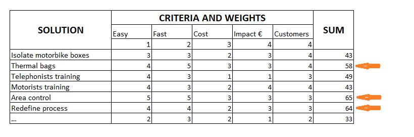

## 6.3 I.3 Assess risks and pilot test

A new process was designed to reduce errors in addresses and redefine areas to serve. It was tested in B1 and M1 for a week.

The following analysis compare the number of errors in the addresses using the new process in B1 and M1 and using the traditional process in B2 and M2.

```r
dataTest<-read.csv("pilot_test.csv",row.names = 1)
summary(dataTest)
```

```
    Group               Error
 Length:1669        Min.   :0.00000
 Class :character   1st Qu.:0.00000
 Mode  :character   Median :0.00000
                    Mean   :0.01378
                    3rd Qu.:0.00000
                    Max.   :1.00000
```

```r
tab<-table(dataTest$Group,dataTest$Error)
x<-c(tab[,2])
x
```

```
Control     New
     20       3
```

```r
n<-rowSums(tab)
n
```

```
Control     New
    817     852
```

```r
prop.test(x,n,alternative = "two.sided")
```

```
    2-sample test for equality of proportions with continuity correction

data:  x out of n
X-squared = 11.982, df = 1, p-value = 0.0005372
alternative hypothesis: two.sided
95 percent confidence interval:
 0.008441519 0.033475836
sample estimates:
     prop 1      prop 2
0.024479804 0.003521127
```

Furthermore, different types of “thermal hot bag” were tested. A test was performed to compare the delivery temperature with and without bag.

```r
dataTest2<-read.csv("pilot_test2.csv",row.names = 1)
summary(dataTest2)
```

```
       t1              t2
 Min.   :77.41   Min.   :72.16
 1st Qu.:85.16   1st Qu.:79.37
 Median :89.81   Median :81.79
 Mean   :88.78   Mean   :81.87
 3rd Qu.:91.62   3rd Qu.:84.80
 Max.   :98.45   Max.   :93.57
```

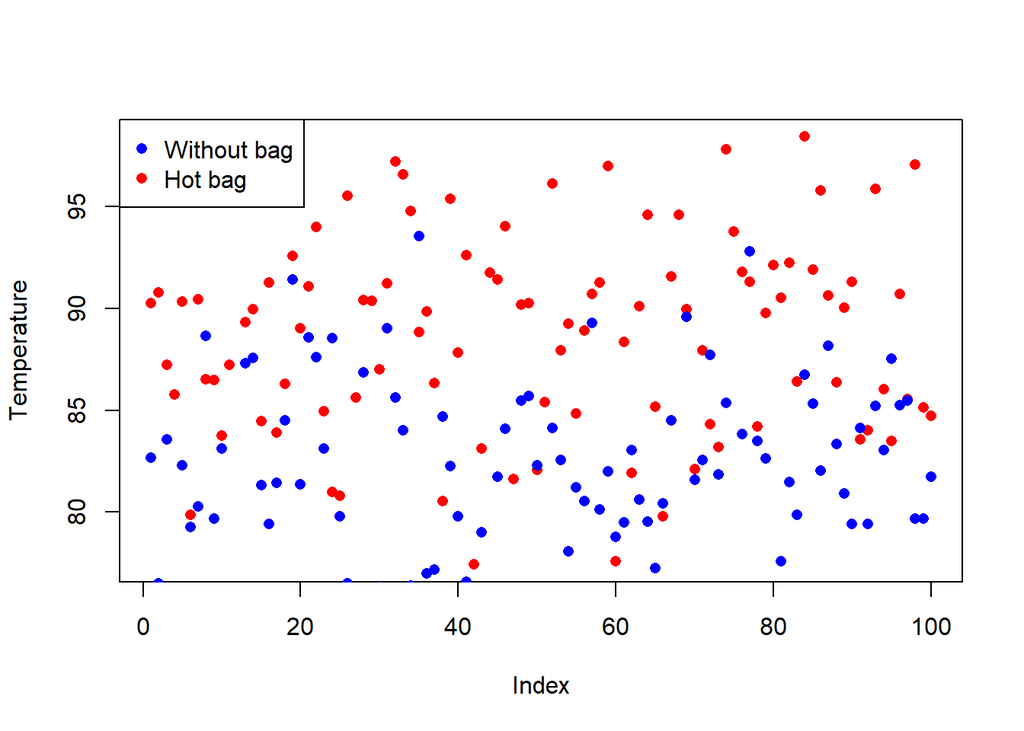

```r
plot(dataTest2$t1,pch=16,col="red",xlab = "Index",ylab = "Temperature")
points(dataTest2$t2,pch=16,col="blue")
legend("topleft",c("Without bag","Hot bag"),col=c("blue","red"),pch=c(16,16))
```

```r
t.test(dataTest2$t1, dataTest2$t2, alternative = "two.sided", var.equal = FALSE)
```

```
    Welch Two Sample t-test

data:  dataTest2$t1 and dataTest2$t2
t = 10.437, df = 197.21, p-value < 2.2e-16
alternative hypothesis: true difference in means is not equal to 0
95 percent confidence interval:
 5.603588 8.214531
sample estimates:
mean of x mean of y
 88.78170  81.87264
```

## 6.4 I.4 Implementation

- A timetable of activities (with responsibles and available resources) was established.
- Managers were trained in the new process and it was launched in the 4 establishments.
- Thermal bags were purchased for all motorists.
- Motorists were trained about the streets in the area and some time was allocated for them to share information learn routes.

# 7 Control

## 7.1 C.1 Standardize

UNDERSTOOD $\Longrightarrow$ DOCUMENTED $\Longrightarrow$ MEASURED $\Longrightarrow$ IMPROVED

## 7.2 C.2 Control at the new level

A tracking system for registering time and temperature was progressively established $\Longrightarrow$ SENSORS

## 7.3 C.3 Non-financial performance assesment

```r
# Time
time_new<-read.csv("time_new.csv",row.names = 1)
summary(time_new)
```

```
       x
 Min.   :15.36
 1st Qu.:19.33
 Median :20.38
 Mean   :20.37
 3rd Qu.:21.38
 Max.   :25.15
```

```r
grid<-c(50:400)/10
fnorm<-dnorm(grid,mean = 20.37,sd=1.5)
fnorm<-cbind(grid,fnorm)

nfaults<-(sum(time_new>25)/N)*1000000
print("faults per million >25")
```

```
[1] "faults per million >25"
```

```r
print(nfaults)
```

```
[1] 10000
```

```r
nfaults<-(sum(time_new>30)/N)*1000000
print("faults per million >30")
```

```
[1] "faults per million >30"
```

```r
print(nfaults)
```

```
[1] 0
```

```r
# Temperature
ttemp_new<-read.csv("ttemp_new.csv",row.names = 1)
summary(ttemp_new)
```

```
       x
 Min.   :77.54
 1st Qu.:82.79
 Median :84.88
 Mean   :85.03
 3rd Qu.:86.66
 Max.   :93.09
```

```r
grid2<-c(750:1000)/10
fnorm2<-dnorm(grid2,mean = 85,sd=3)
fnorm2<-cbind(grid2,fnorm2)

nfaults<-(sum(ttemp_new<80)/nrow(ttemp_new))*1000000
print("faults per million <80")
```

```
[1] "faults per million <80"
```

```r
print(nfaults)
```

```
[1] 40000
```

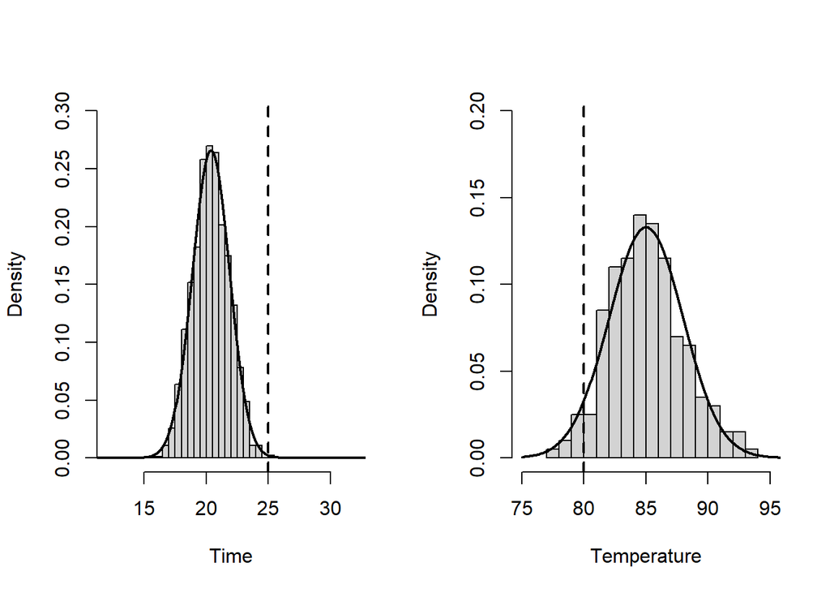

```r
par(mfrow=c(1,2))
hist(time_new$x,xlim = c(12,32),ylim = c(0,0.3),probability = T,xlab="Time",main ="" ,20)
lines(grid,fnorm[,2],type="l",lwd=2,lty=1)
abline(v=25,lwd=2,lty=2)

hist(ttemp_new$x,xlim = c(75,95),ylim = c(0,0.2),probability = T,xlab="Temperature",main = "",20)
lines(grid2,fnorm2[,2],type="l",lwd=2,lty=1)
abline(v=80,lwd=2,lty=2)
```

## 7.4 C.3 Financial performance assessment

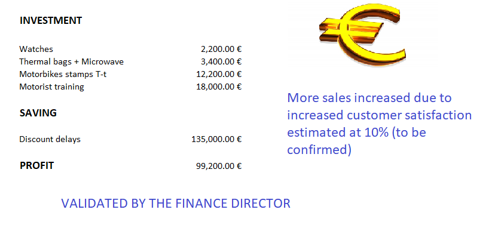

## 7.5 C.4 Close the project (being aware of the things not yet finished)

- Project documentation
- Lessons learned
- Celebration and recognition

END